# Homework 1

Federico Veronesi

2023-09-25

## Exercise 1

### K-means with k=3 and unscaled data (comparison with macro-areas)

```r
oliveoil <- read.csv("oliveoil.DAT", sep = " ")
set.seed(1234)
clust_data1 <- oliveoil[3:10]
kmeans3_unscaled <- kmeans(x = clust_data1, centers = 3, nstart = 100)
oliveoil$cluster <- kmeans3_unscaled$cluster
table(oliveoil$cluster, oliveoil$macro.area)
```

```
##
##     Centre.North Sardinia South
##   1          134        0    42
##   2            0       22   190
##   3           17       76    91
```

The resulting clusters don’t match that much with the macroareas. Especially cluster n°3 includes many observations from both Sardinia and South.

### K-means with k=3 and scaled data (comparison with macro-areas)

```r
set.seed(1234)
clustdata2 <- scale(clust_data1, T, T)
kmeans3_scaled <- kmeans(x = clustdata2, centers = 3, nstart = 100)
oliveoil$cluster2 <- kmeans3_scaled$cluster
table(oliveoil$cluster2, oliveoil$macro.area)
```

```
##
##     Centre.North Sardinia South
##   1           30       98   102
##   2            0        0   219
##   3          121        0     2
```

The k-means with scaled data seems to be a little bit better but the problem described before is still present. It seems reasonable to assume that the features of Sardinia’s products are quite similar to the ones of southern products and the algorithm struggles in finding differences between them.

### K-means with k=9 and unscaled data (comparison with regions)

```r
set.seed(1234)
kmeans9_unscaled <- kmeans(clust_data1, centers = 9, nstart = 100)
oliveoil$cluster3 <- kmeans9_unscaled$cluster
table(oliveoil$cluster3, oliveoil$region)
```

```
##
##     Apulia.north Apulia.south Calabria Liguria.east Liguria.west Sardinia.coast
##   1            2            0        0            0           39              0
##   2            0            3        0            0            3              0
##   3            0           30        0            0            0              0
##   4           13            0        0           16            2              0
##   5            0           16        0            0            0             33
##   6            9            0        5           32            5              0
##   7            0           75        0            0            0              0
##   8            0           77        3            0            0              0
##   9            1            5       48            2            1              0
##
##     Sardinia.inland Sicily Umbria
##   1               0      5      0
##   2              65      1      0
##   3               0      1      0
##   4               0      2     51
##   5               0      0      0
##   6               0      7      0
##   7               0      2      0
##   8               0      7      0
##   9               0     11      0
```

### K-means with k=9 and scaled data (comparison with regions)

```r
set.seed(1234)
kmeans9_scaled <- kmeans(clustdata2, centers = 9, nstart = 100)
oliveoil$cluster4 <- kmeans9_scaled$cluster
table(oliveoil$cluster4, oliveoil$region)
```

```
##
##     Apulia.north Apulia.south Calabria Liguria.east Liguria.west Sardinia.coast
##   1            0            0        0           10           50              0
##   2            1            0        0            7            0              0
##   3           22            0        0            0            0              0
##   4            0            1       23            0            0              0
##   5            2           12       32            0            0              0
##   6            0            0        0            0            0             33
##   7            0            0        1           33            0              0
##   8            0           49        0            0            0              0
##   9            0          144        0            0            0              0
##
##     Sardinia.inland Sicily Umbria
##   1               0      0      0
##   2               0      0     50
##   3               0      6      0
##   4               0     12      0
##   5               0     16      0
##   6              65      0      0
##   7               0      0      1
##   8               0      2      0
##   9               0      0      0
```

### Conclusions on 9-means clustering

The results are quite satisfactory, since in almost all the clusters there is one dominant region: the algorithm captured quite well the differences between regions. However, some areas such as Calabria and Apulia-South are prevalent in two clusters: one possible explanation for this is the high number of observations for these areas (especially for Apulia-South), which could lead to different features between products (-> high variability) and store products from the same region in different clusters. On the opposite side of the problem, regions with less observations (such as Sicily) does not identify precisely to one cluster, but their products belong to different groups together with observations from other regions.

## Exercise 2

The result of the clustering will depend on three steps: the choice of the initial centroids, the computation of the new centroids at every step, and the minimization of the objective function.

### Initial centroids

The choice of the initial centroids is randomic, so they will be k random observations which correspond to k observations from the original dataset multiplied by the quantity q.

### Newly obtained Centroids

Step by step, the new centroids are computed as:

$m_k=\frac{1}{n_k} \sum{x_i*q}= \frac{q}{n_k} \sum{x_i}$

For this reason, the k final centroids of the clusters will be the same obtained with D, multiplied by the constant q.

### Minimization of the euclidean distance

This step is performed using the tranformed observations $x_i*q$ and the centroids:

$\sqrt{\sum_{i=1}^{n}{(q*x_i-q*m_{c(i)})}^2}=\sqrt{q^2\sum_{i=1}^{n}{(x_i-m_{c(i)})}^2}=q*\sqrt{\sum_{i=1}^{n}{(x_i-m_{c(i)})}^2}$

The euclidean distance computed in the transformed dataset is equal to the one computed in the original dataset, multiplied by a constant q. This constant doesn’t affect the minimization, so at every step the algorithm minimizes the euclidean distance as it would have done in the original dataset.

## Exercise 3

### Scatterplot

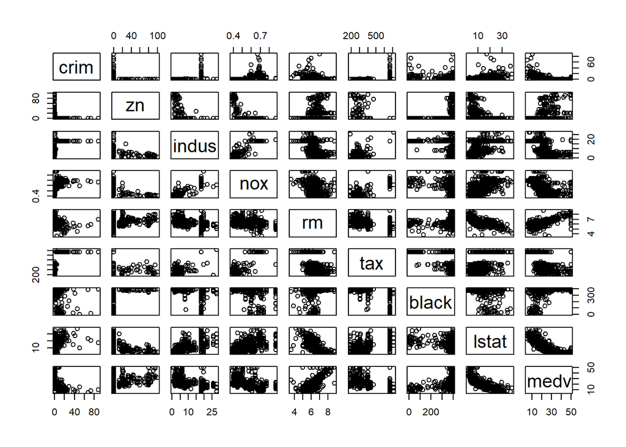

```r
boston <- read.csv("boston.DAT", sep = " ")
plot(boston[,-c(4,7:9,11)])
```

### Correlation between variables

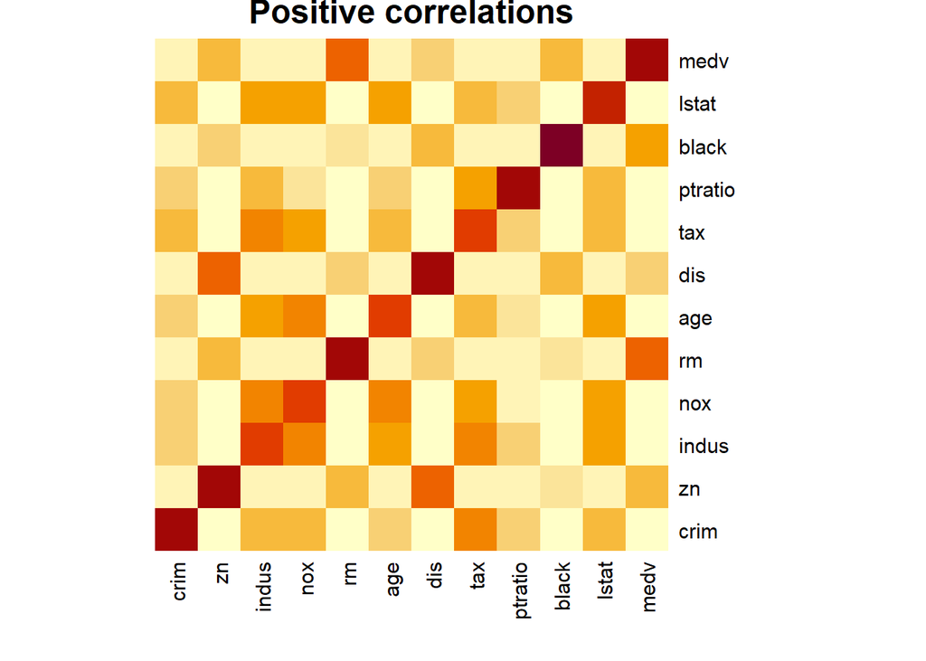

```r
heatmap(cor(boston[,-c(4,9)])*(cor(boston[,-c(4,9)])>0), Rowv = NA, Colv = NA, main = "Positive correlations")
```

[output not shown]

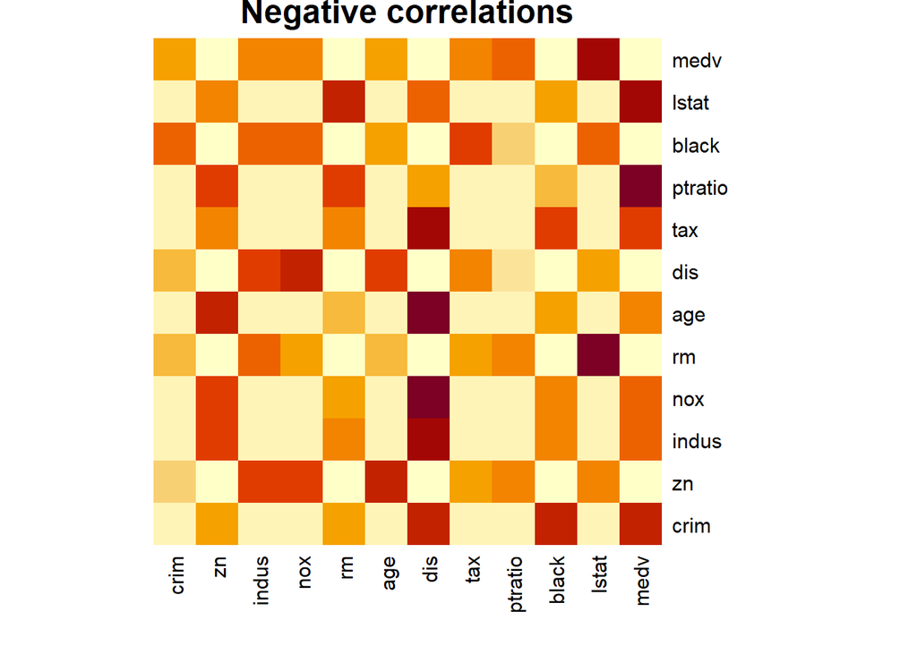

```r
heatmap(abs(cor(boston[,-c(4,9)]))*(cor(boston[,-c(4,9)])<0), Rowv = NA, Colv = NA, main = "Negative correlations")
```

### K-means clustering

The k-means is performed using standardized variables, in order to avoid problems related to their magnitude. Here I decided to remove the two categorical variables (chas and rad), because they could be confusing in performing the standardization and in the computation of the euclidean distances.

#### Elbow plot

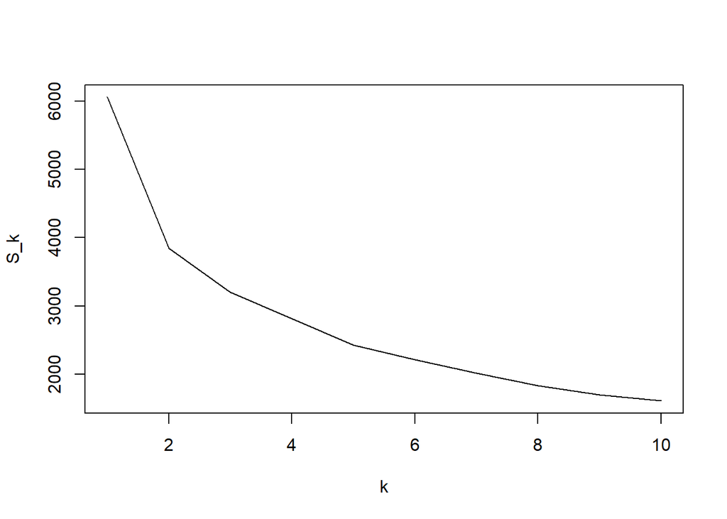

```r
boston_clust <- scale(boston[,-c(4,9)], T, T)
sk <- numeric(0)
kclusterings <- list()
for (k in 1:10){
kclusterings[[k]] <- kmeans(boston_clust,k,nstart=100)
sk[k] <- kclusterings[[k]]$tot.withinss
# This is the component that has the S_k
}
plot(1:10,sk,xlab="k",ylab="S_k",type="l")
```

Despite this plot could be misleading, we can say that two possible values for k are 2 or 5.

#### 5-means clustering

```r
km5 <- kmeans(boston_clust, centers=5, nstart = 100)
boston_clust <- as.data.frame(boston_clust)
boston_clust$cluster <- km5$cluster
```

#### PCA and visualization of clusters

```r
library(fpc)
```

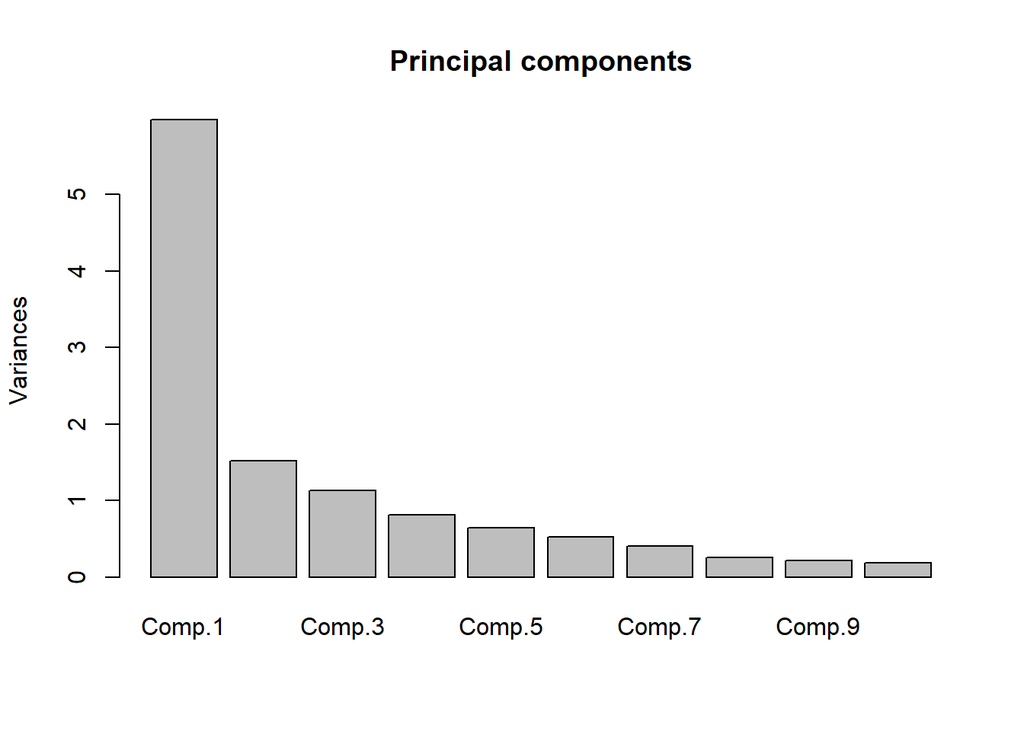

```r
pcboston <- princomp(boston_clust[,-13])
plot(pcboston,main="Principal components")
```

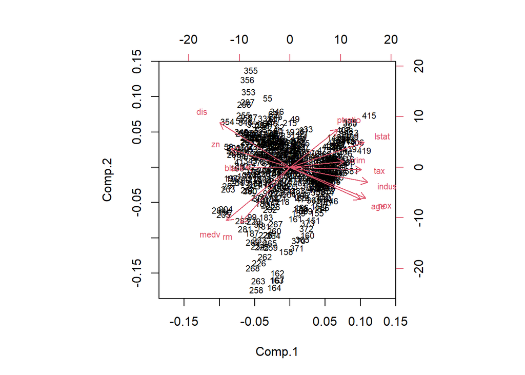

```r
biplot(pcboston,cex=0.7) # Biplot with variable axes
```

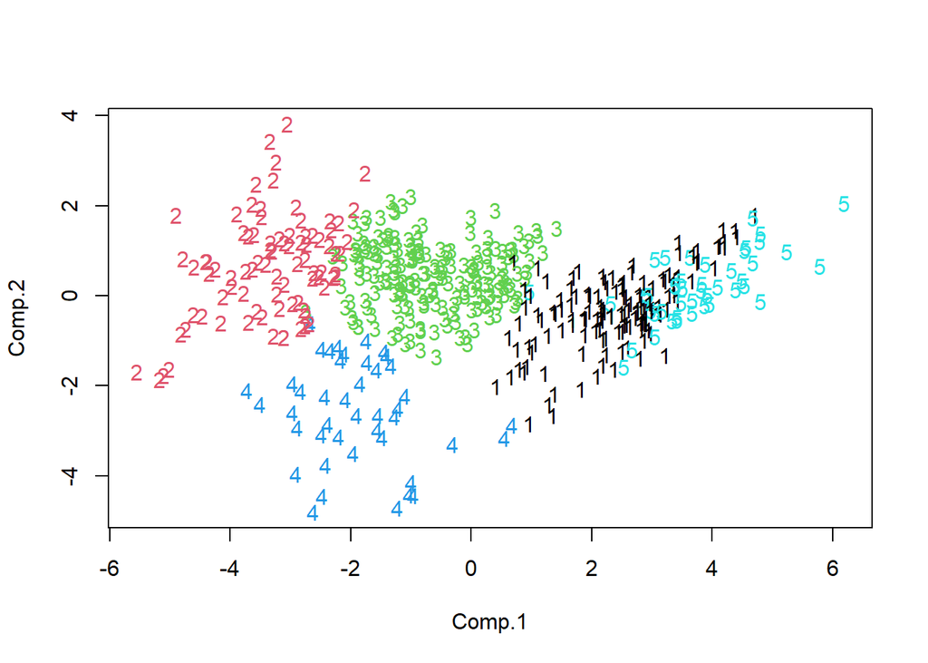

```r
plot(pcboston$scores,col=boston_clust$cluster,pch=clusym[boston_clust$cluster])
```

#### 2-means clustering

```r
boston_clust <- scale(boston[,-c(4,9)], T, T)
km2 <- kmeans(boston_clust, centers=2, nstart = 100)
boston_clust <- as.data.frame(boston_clust)
boston_clust$cluster <- km2$cluster
```

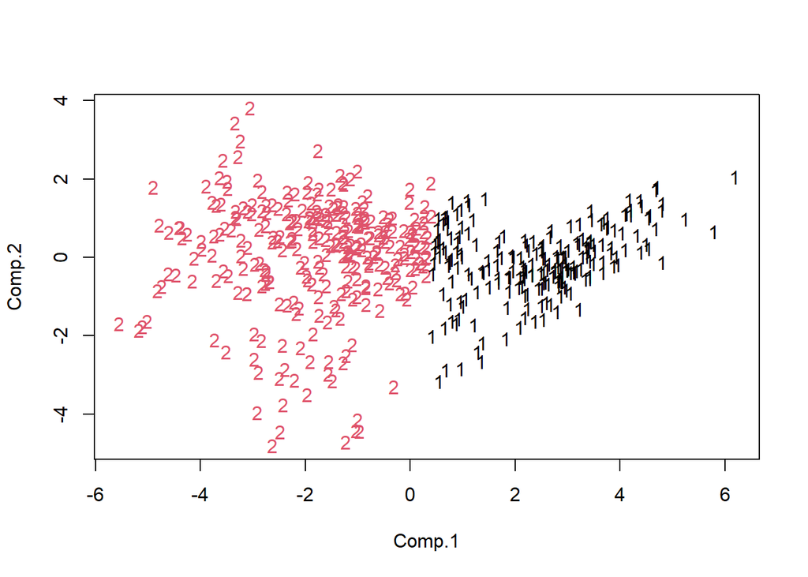

```r
plot(pcboston$scores,col=boston_clust$cluster,pch=clusym[boston_clust$cluster])
```

## Exercise 4

### K-means with 1 initialization, K-means with 100 initializations and K-means++

```r
library(pracma)
```

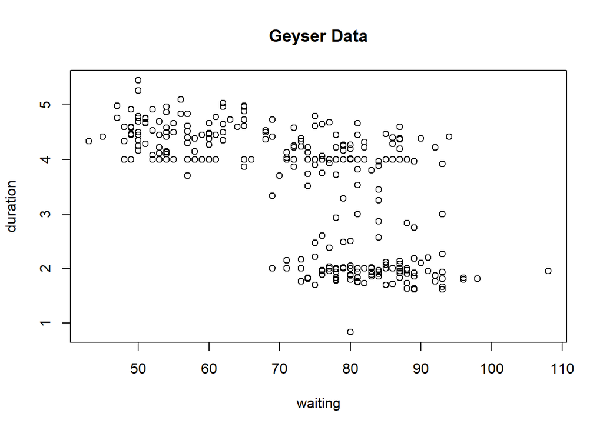

```r
kmpp <- function(X, k) {
        n <- nrow(X)
        C <- numeric(k)
        C[1] <- sample(1:n, 1)
        for (i in 2:k) {
          dm <- distmat(X, X[C, ])
          pr <- apply(dm, 1, min); pr[C] <- 0
          C[i] <- sample(1:n, 1, prob = pr)
        }

        kmeans(X, X[C, ])
}

geyser <- read.csv("geyser.dat", sep = " ")

plot(geyser, main = "Geyser Data")
```

```r
geyser <- as.matrix(geyser)
set.seed(1111)
kmeanspp <- kmpp(geyser, k=3)
set.seed(1234)
kmeans1 <- kmeans(geyser, 3, nstart = 1)
set.seed(2345)
kmeans100 <- kmeans(geyser, 3, nstart = 100)
kmeans1$tot.withinss
```

```
## [1] 6388.563
```

```r
kmeans100$tot.withinss
```

```
## [1] 6284.214
```

```r
kmeanspp$tot.withinss
```

```
## [1] 6284.214
```

The within-sum of squares is greater for the k-means with 1 initialisation, while the within SS of the k-means++ coincides with the one for the k-means with 100 initializations. This makes sense because the k-means++ improves the value of the objective function through a smarter choice of the initial centroids, as does the randomization.

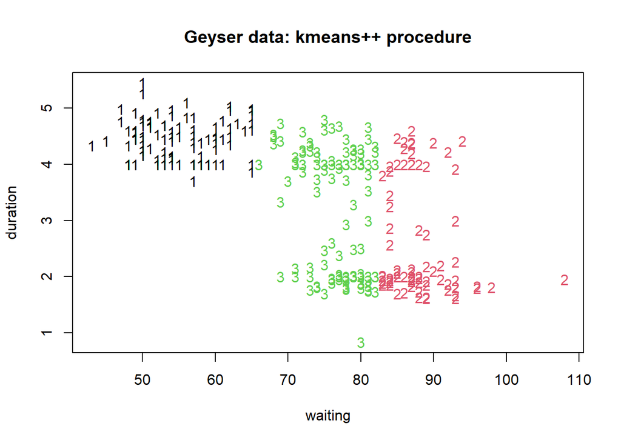

```r
library(fpc)
plot(geyser,col=kmeanspp$cluster,pch=clusym[kmeanspp$cluster], main = "Geyser data: kmeans++ procedure")
```